# Case Study

Cantilever beam

Thyge Vinther Ludvigsen, s203591

10 Apr, 2026

# Introduction

## Goal of the case study

What I test in this case study:

- simple link function/ Error function.
- overall workflow.
- Evaluation methods of the Bayesian risk

Note:

- compute the full sensor solution space
  - no optimization, no sensor selection, no sensor placement.

# Methodology

## Chosen Features

Modal properties:

- 2 first natural frequencies

Features:

- 2 first natural frequencies

## Cost function

- Total Cost
- Sensor Cost’s
- Prediction Cost Matrix
- Sensor Cost

$$C_\text{total} = C_\text{prediction}(H, d) + C_\text{sensors}(e)$$

$$C_\text{sensors}(e) = 5 + 1 \cdot \text{number of sensors}$$

$$C_\text{prediction} = \begin{bmatrix}
0 & 5 \\
100 & 10
\end{bmatrix} =
\begin{bmatrix}
\text{True Negative} & \text{False Positive} \\
\text{False Negative} & \text{True Positive}
\end{bmatrix}$$

where:

- Positive: is the prediction of damage.
- Negative: is the prediction of no damage.
- True Positive (TP): Correctly predicting damage when it is present.
- False Positive (FP): Incorrectly predicting damage when it is not present.
- True Negative (TN): Correctly predicting no damage when it is not present.
- False Negative (FN): Incorrectly predicting no damage when there is actually damage.

```python
# C [H, d] = the prediction cost
prediction_cost = np.array([[0,   5],  # TN, FP
                            [100, 10]   # FN, TP
                            ])

H = 1; d = 1
print(f"Prediction cost: {prediction_cost[H, d]}, which is the cost of predicting {d} when the true state is {H}.")

def sensor_cost(n_sensors):
    return 5 + 1 * n_sensors
```

```
Prediction cost: 10, which is the cost of predicting 1 when the true state is 1.
```

## Prior distribution

- Theory
- Venn diagram
- Code

No Damage and Damage:
$$P(H_0) = P(\theta_0) = 0.90$$

$$P(H_1) = 1 - P(H_0)$$

Assume that all damage states with damage are equally likely

$$P(\theta_i \mid H_1) = \frac{1}{N} \quad \text{for } i = 1, 2, ..., K$$

This gives. (Remember that $P(\theta_i) = P(\theta_i, H_1)$ since $\theta_i$ can only occur if $H_1$ is true)
$$P(\theta_i) = P(\theta_i, H_1) = P(H_1) P(\theta_i \mid H_1) = P(H_1) \frac{1}{N} \quad \text{for } i = 1, 2, ..., K$$

where $N$ is the number of damage states considered.

- n is the number of elements
- k is the number of damaged elements
- the binomial coefficient $\frac{n!}{k!(n-k)!}$ gives the number of ways to choose k damaged elements from n total elements.

$P(\theta_i) = P(\theta_i, H_1)$

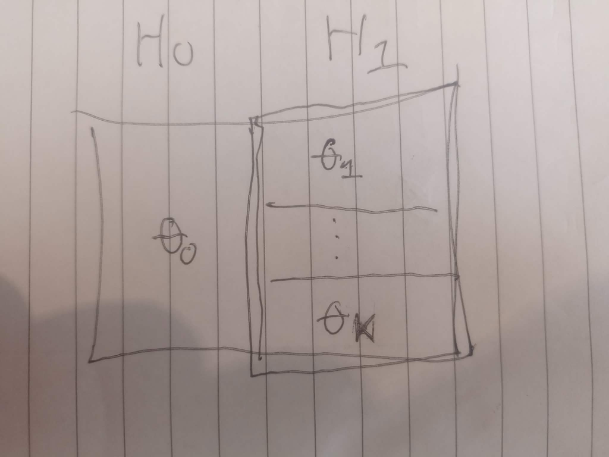

```python
P_H0 = 0.9
P_H1 = 1-P_H0

prior = np.zeros(16)
prior[0] = P_H0
prior[1:] = P_H1/len(prior[1:])

print(f"prior: {prior}")
```

```
prior: [0.9        0.00666667 0.00666667 0.00666667 0.00666667 0.00666667
 0.00666667 0.00666667 0.00666667 0.00666667 0.00666667 0.00666667
 0.00666667 0.00666667 0.00666667 0.00666667]
```

# Error function $\epsilon(e)$

Note: this error function is only for the estimation of the natural frequencies.

$$\epsilon_{\omega}(e) = \epsilon_0(e) + ... + \epsilon_n(e)$$

Each error term explains a different source of error in the estimation of the natural frequencies. I assume that the function above can be constructed in a way where all the error terms are independent, and that the total error can be calculated as the sum of the individual error terms. (This is not True, example of signal to noise ratio and the effect of temperature to the stiffness of the structure.)

## Error form Sensor signal noise

- Model
- $\bar{X} \sim \mathcal{N}\left(\mu, \frac{1}{n^2}\sum_{i=1}^n \sigma_i^2\right)$

**Assumptions**

1. I assume that the natural frequencies is estimated as the mean of all the OMA estimations of the natural frequencies for all the sensor locations.
   - $\hat{\omega} = \frac{1}{n} \sum_{i=1}^n \omega_i$ where $\omega_i$ is the estimation of the natural frequencies from sensor location $i$.
2. I assume that the error from environmental effects to be independent of the sensor noise.
3. I assume that the error from the sensor noise in the prediction of the natural frequencies is normally distributed, and that the variance of this error is a function of the sensor locations and the sensor noise level.

This assumptions leads to.

$$\epsilon_{vibration} \sim \mathcal{N}(0, \frac{1}{\# e_{vibration}^2}\sum_{i=1}^{\# e_{vibration}} \sigma(e_{vibration, i})^2)$$

Where:

- $\epsilon_{vibration}$ is the error from sensor noise in the estimation of the natural frequencies.
- $\#$ is the count operator.
- $\sigma(e_{vibration, i})$ is the standard deviation of the error for an given sensor $i$.

**Important**

We can have an increasing error with more sensors, if the error from the sensor noise is high.

We have $n$ independent normal distributions where we make 1 draw from each distribution.

$X_1, X_2, \dots, X_n \text{ independent, } X_i \sim \mathcal{N}(\mu, \sigma_i^2)$

we compute the sample mean.

$\bar{X} = \frac{1}{n}\sum_{i=1}^n X_i$

now do we find the distribution of $\bar{X}$, it is know that the sample mean of a normal distribution is also normally distributed.

$$\mathbb{E}[\bar{X}] = \mathbb{E}\left[\frac{1}{n}\sum_{i=1}^n X_i\right] = \frac{1}{n}\sum_{i=1}^n \mathbb{E}[X_i] = \frac{1}{n}(n\mu) = \mu$$

the draws are independent so the variance of the sample mean is:

$$\mathrm{Var}(\bar{X}) = \mathrm{Var}\left(\frac{1}{n}\sum_{i=1}^n X_i\right)
= \frac{1}{n^2} \sum_{i=1}^n \sigma_i^2$$

note: $1/n^2$ is from the scaling rule of the variance $Var(aX + b) = a^2 Var(X)$, it can easily be seen by moving $1/n$ inside the sum.

final result:

$$\bar{X} \sim \mathcal{N}\left(\mu, \frac{1}{n^2}\sum_{i=1}^n \sigma_i^2\right)$$

[Linear combination of non independent random variables](https://en.wikipedia.org/wiki/Variance#Linear_combinations)

## Std, $\sigma(e_{vibration, i})$

- Variables
- Simplest model
- More complex model ??

Modal variables:

- Natural frequencies: $\omega_1, \omega_2$
- Mode shapes: $\phi_1, \phi_2$
- Participation factors: $\Gamma_1, \Gamma_2$
  - Needs to be the participation in the response of tee structure for an given ambient excitation.
  - Assume it to be the same as mass participation factors ?

Model setup variables:

- Sensor configuration: $e_{dva}$
- length of the signal, $T$
  - number of cycles captured in the signal, $n_c$
  - number of samples captured in 1 cycle for an given mode, $n_s$
  - sampling frequency of the signal, $f_s$

Ambient excitation variables:

- Amplitude of the Mode shape given the ambient excitation. $A_{i}$
- The Ambient excitation effect the participation factors for each mode, it is dependent on the frequency content of the ambient excitation.

Sensor variables:

- Signal to noise ratio (SNR) of the sensor
- Sampling frequency of the sensor, Hz $f_s$
- Sensor type (accelerometer, velocity sensor, displacement sensor)
- Sensor location ($e_{dva}$)

**Minimum require**

1. The model need to weight the positions of the sensors.
   - use mode shapes
2. and the number of sensors.
   - this is don in for the variance of the distribution function for the mean error $\frac{1}{n^2}\sum_{i=1}^n \sigma_i^2$

$$\sigma(e_{vibration, i}) = \omega_i \cdot 5\% \cdot f(\phi_i(e_{vibration, i}))$$

An more complex model need to both include almost all of the Variables. Time and testing is need to formulate this model

## Code example

```python
def sigma_vibration(omega, phi, node_number):
    # assumed sensor coefficient of variation (CV)
    CV = 0.05
    # calculate vibration standard deviation
    sigma = omega * CV * (10 - 9 * abs(phi[node_number]))
    return sigma

print(f"omega_1 = {omega_1:.2f} s^-1, mode shape phi_1 = {phi_1}")
print(f"omega_2 = {omega_2:.2f} s^-1, mode shape phi_2 = {phi_2}")

node_number = 4
print(f"node {node_number}: sigma_vibration for mode 1 = {sigma_vibration(omega_1, phi_1, node_number):.4f}")
print(f"node {node_number}: sigma_vibration for mode 2 = {sigma_vibration(omega_2, phi_2, node_number):.4f}")
```

```
omega_1 = 1.04 s^-1, mode shape phi_1 = [0.         0.09252781 0.32807894 0.64695444 1.        ]
omega_2 = 6.72 s^-1, mode shape phi_2 = [ 0.          0.50514687  1.          0.54397217 -0.72646916]
node 4: sigma_vibration for mode 1 = 0.0522
node 4: sigma_vibration for mode 2 = 1.1635
```

# Evaluation of the Bayesian risk

# Setup FEM model

## Geometry

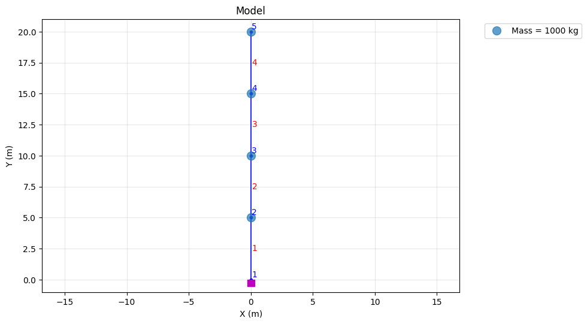

## Mode Shapes

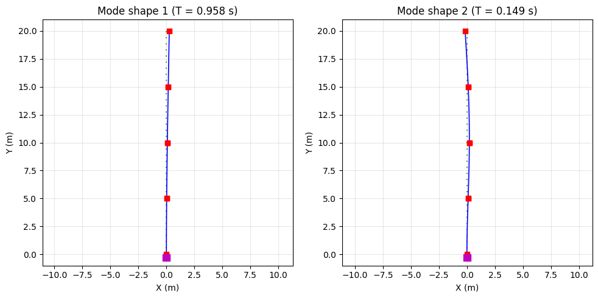

## Damaged scenarios

```
Damage scenarios:
[(0, 0, 0, 0), (0, 0, 0, 1), (0, 0, 1, 0), (0, 0, 1, 1), (0, 1, 0, 0), (0, 1, 0, 1), (0, 1, 1, 0), (0, 1, 1, 1), (1, 0, 0, 0), (1, 0, 0, 1), (1, 0, 1, 0), (1, 0, 1, 1), (1, 1, 0, 0), (1, 1, 0, 1), (1, 1, 1, 0), (1, 1, 1, 1)]
Plot of case: (1, 1, 1, 1):
```

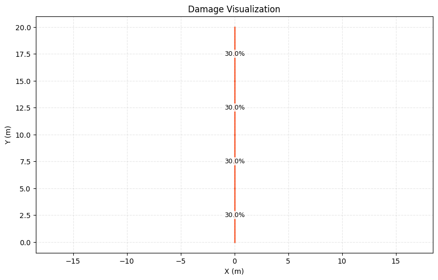

## 2 first natural frequencies

```
Undamaged case:
Natural frequencies (Hz = s^-1): [1.04366091 6.72223044]

Damaged cases:
Natural frequencies (Hz = s^-1):
[[1.04216338 6.56894051]
 [1.02799282 6.20647943]
 [1.02654082 6.08678703]
 [0.9876046  6.48179787]
 [0.98632241 6.35293945]
 [0.97420484 6.04205401]
 [0.97295864 5.93749723]
 [0.92280709 6.40000981]
 [0.92179618 6.26272527]
 [0.91208959 5.90803922]
 [0.91110134 5.79986249]
 [0.88355697 6.12967195]
 [0.88266002 6.0165504 ]
 [0.87406728 5.71685271]
 [0.87318936 5.6242215 ]]
```

## Analysis

# Results

## Risk for Uninformed system

Assuming that.

- the decision is always $d_0$ (no damage predicted).
- we can use the prior distribution to calculate the risk for this decision.

$$R(d_0) = C_\text{prediction}(H_0, d_0) \cdot P(H_0) + C_\text{prediction}(H_1, d_0) \cdot P(H_1)$$

```python
# C [H, d] = the prediction cost
prediction_cost[0, 0] * P_H0 + prediction_cost[1, 0] * P_H1
```

```
np.float64(9.999999999999998)
```